# C7.24 例題：Y型補強板パネルの計算

Fig. C7.22a に示すような Y 型補強板パネルの圧縮一体破壊応力を Gerard 法によって計算する。Fig. C7.31 に補強パネル構成単位の寸法詳細を示す。

補強材（スチフナー）は 2014-T6 アルミニウム合金の押出材で、その物性は $F_{cy} = 53,000\text{ psi}$ 、および $E_c = 10,700,000\text{ psi}$ である。

外板（スキンまたはパネルシート）は 7075-T6 アルミニウム合金板で、その物性は $F_{cy} = 67,000\text{ psi}$ 、および $E_c = 10,500,000\text{ psi}$ である。

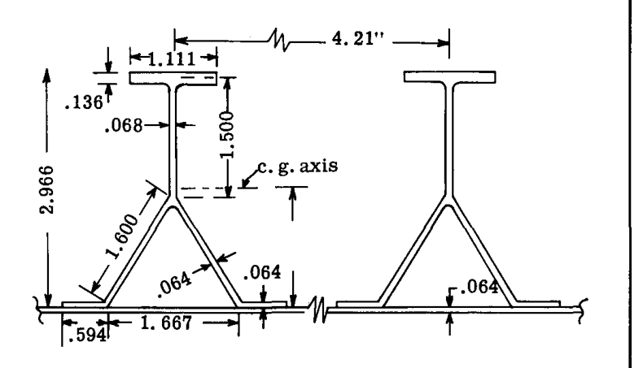

Fig. C7.31

補強材の断面積 $= 0.538\text{ in.}^2$  
外板の断面積 $= 4.21 \times 0.064 = 0.270\text{ in.}^2$  
補強材1単位あたりの総断面積 ( $A$ ) $= 0.808\text{ in.}^2$  
補強材単体の断面二次半径 $= 1.123\text{ in.}$

### 解答

Y 型補強材を構成する各要素の板厚が異なるため、式(C7.29)を用いて有効板厚 $t_w$ を求める必要がある。

$$\bar{t}_w = \frac{\sum b_i t_i}{\sum b_i} = \frac{1.111 \times 0.136 +
1.432 \times 0.068 + 3.2 \times 0.064 + 1.188 \times 0.064}{1.111 +
1.432 + 3.2 + 1.188}$$

または

$$\bar{t}_w = 0.0763\text{ インチ}$$

$F_{cs(M)}$ の方程式を解くために Fig. C7.7 の曲線を使用する。 $\bar{t}_w$ および $\bar{F}_{cy}$ で修正された Fig. C7.7 の下部スケールパラメータは以下の通りである。

$$\frac{A}{g \cdot \bar{t}_w \cdot t_s} \left( \frac{\bar{F}_{cy}}{E_c}
\right)^{1/2}$$

6つの補強材を持つパネルの平均値として、Fig. C7.22a から得られる $g$ の値は $18.83$ である。 $E_c$ は補強材と外板の平均的な $E$ として $10,600,000\text{ psi}$ とする。これらを上記パラメータに代入すると、

$$\left( \frac{0.808}{18.83 \times 0.0763 \times 0.064} \right) \left(
\frac{64,700}{10,600,000} \right)^{1/2} = 0.686$$

Fig. C7.7 にプロットされている曲線は $t_i / t_s$ 比が $1.0$ のものである。我々のパネルの比率は $0.0763 / 0.064 = 1.19$ である。Fig. C7.30 からの補正係数は $1.03$ である。したがって、

$$F_{cs(M)} = 1.03 \times 48,200 = 49,600\text{ psi}$$

補強材と外板の1ユニットが支持できる荷重は、

$$= 0.808 \times 49,600 = 40,100\text{ lb}$$

## C7.25 不安定な断面を持つ部材の柱強度曲線

第C2章では、安定した断面を持つ部材の柱強度について扱った。例えば、比較的肉厚の厚い円管を様々な長さで圧縮試験して破壊応力を求め、これらの応力値 $F_c$ を部材の細長比 $L'/\rho$ に対してプロットすると、試験結果は Fig. C7.32 の曲線 ABFC に極めて近くなる。破壊の形態は、点 B-C 間の応力では弾性全体曲げ不安定（座屈）となり、BA の範囲の大部分の応力では非弾性曲げ不安定となる。Fig. C7.32 に示す Euler の式は、弾性および非弾性曲げ不安定の両方における破壊応力の決定に使用でき、非弾性応力範囲では接線係数 $E_t$ が用いられる。

ここで、曲線 ABC を得るために使用したのと同じ材料で、チャンネルやハットセクションなどの、肉厚が比較的薄い開断面の部材を用いて、様々な長さの試験を行うと仮定する。このような部材の試験結果は、しばしば Fig. C7.32 の DEFC に類似した曲線に沿うことになる。したがって、実際の破壊応力は Euler の柱公式によって与えられる値よりもはるかに低いため、DEF の範囲では Euler の式を使用できないことは明らかである。 $L'/\rho$ が 20 未満の短い部材は、ほぼ同一の応力で破壊するため、 $L'/\rho = 20$ までの長さに対する破壊応力はほぼ一定であり、この応力は圧壊応力（ $F_{cs}$ ）と名付けられている。本章のこれまでの部分では、この局所的な圧壊応力または破壊応力の計算方法について扱ってきた。点(F)において、断面の一部の弾性座屈が開始する。応力点 F から E の間では、部材の挙動は全体の弾性曲げ不安定と、応力増加に伴って広範囲化する局所座屈の両方が関与する。柱強度曲線の EF の部分は、しばしば遷移領域と呼ばれる。現在のところ、この遷移領域における破壊応力を決定するための信頼できる理論は開発されていないため、試験結果に対して検証され、適度に整合する結果を与えることが確認されている半経験的な方法に頼っている。

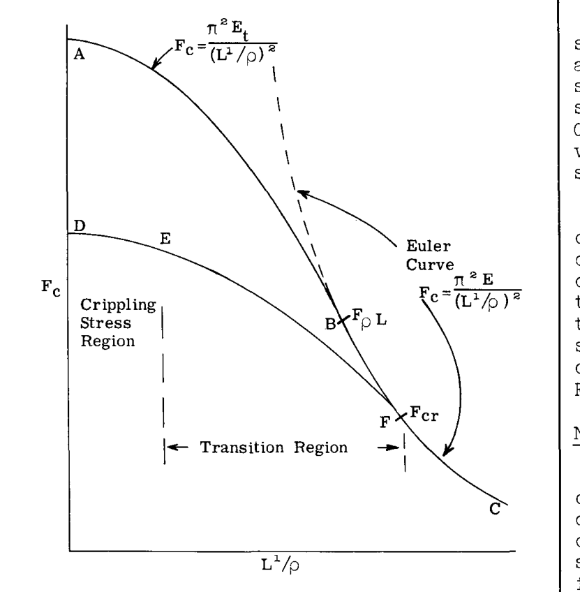

Fig. C7.32

## C7.26 遷移領域における柱破壊応力の決定方法

### 方法1. JOHNSON-EULERの方程式

Fig. C7.32 の遷移領域 EF における柱破壊応力 $F_c$ の計算に最初に使用された方法は、圧壊応力を用いた有名な Johnson-Euler の方程式である。その式は以下の通りである。

$$F_c = F_{cs} - \frac{F_{cs}^2}{4\pi^2 E} (L'/\rho)^2 \qquad
\text{--- (C7.31)}$$

ここで、  
$F_c =$ 柱の破壊応力 (psi)  
$F_{cs} =$ 圧壊応力。 $L'/\rho = 0$ で発生すると仮定する。ただし $L' = L/\sqrt{c}$ である。

この方程式は、 $L'/\rho = 0$ における圧壊応力から始まる放物線を与え、圧壊応力の半分に等しい応力値において Euler 曲線に接する。Fig. C7.33 は、アルミニウム合金材料について、様々な圧壊応力値（ $L'/\rho = 0$ における応力 $F_c$ ）に対する式(C7.31)をプロットしたものである。

### 方法2.

以下の方法、あるいはそのわずかな変形は、多くの航空宇宙企業の構造設計マニュアルに掲載されている。いわゆる遷移領域における柱破壊応力を決定するためのこの方法または手順は、安定な断面に対する基本的な柱曲線を使用する。この手順は Fig. C7.34 を参照することで最もよく説明できる。

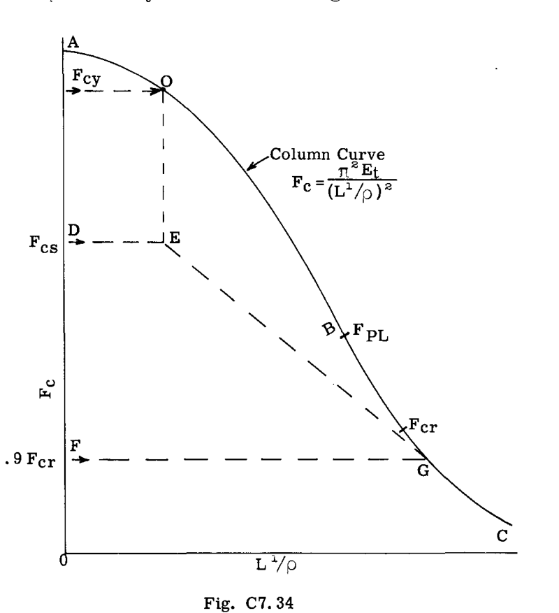

Fig. C7.34

曲線 ABC は、安定な断面を持ち、与えられた材料に対する Euler の柱曲線である。これには非弾性応力範囲での接線係数 $E_t$ の使用が含まれる。いわゆる遷移領域に対する柱強度曲線を決定するために、以下の手順が取られる。

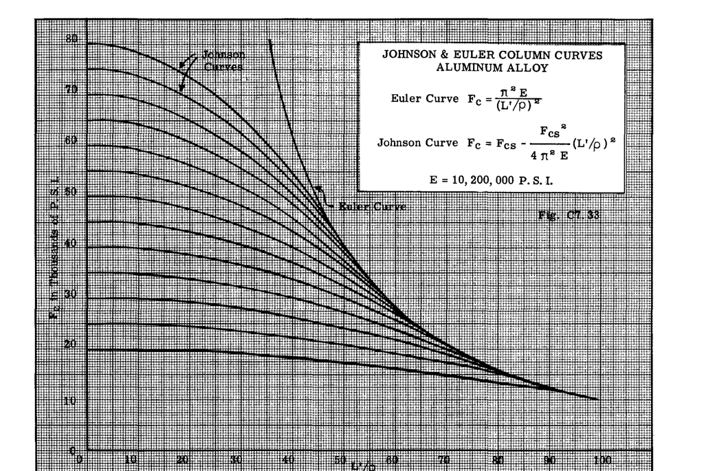

Fig. C7.33

1. 使用している特定の材料の降伏応力 $F_{cy}$ に等しい $F_c$ 値を通る水平線を引き、基本柱強度曲線上の点(O)を決定する。
2. 点 D から始まる水平線を描く。点 D は、検討対象の柱断面の圧壊応力（ $F_{cs}$ ）に等しい $F_c$ 値にある。この線上の点(E)は、点(O)から垂直に下ろした交点として決定される。
3. $F_c = 0.9 F_{cr}$ の値に点(F)を配置する。ここで $F_{cr}$ は断面の座屈応力である。点(F)を通る水平線を引き、基本柱強度曲線との交点を点(G)とする。
4. 点 E と G を直線で結ぶ。この直線 EG は、点 E と G の間の $L'/\rho$ の値に対する柱破壊応力 $F_c$ を表す。

この方法は、安定な断面に対する柱強度の使用と、座屈応力の決定を必要とするため、方法1よりも多くの計算が必要となる。また、作図による構成も必要となる。

### 方法3.

広く使用されているもう一つの方法は、遷移領域における柱強度を表すために放物線を使用するものである（文献12を参照）。

放物線近似は以下の形式を持つ。

$$\frac{F_c}{F_{cs}} = 1 - \left(1 - \frac{F_{cr}}{F_{cs}}\right)
\left(\frac{F_{cr}}{F_E}\right) \qquad \text{--- (C7.32)}$$

ここで、  
$F_c$ は柱の破壊応力。  
$F_{cs}$ は圧壊応力。  
$F_{cr}$ は柱断面の座屈応力。  
$F_E$ は、検討対象の柱に対する Euler の柱応力であり、方程式 $F_E = \pi^2 E / (L'/\rho)^2$ から求められる。

この方程式は $F_c > F_{cr}$ に対して適用される。 $F_{cr} > F_{pL}$ （ここで $F_{pL}$ は材料の比例限度応力）となる場合は、式(C7.32)において $F_{cr}$ の代わりに $F_{pL}$ を使用する。

# C7.27 不安定な断面を持つ柱の強度に関する例題

### 問題1.

長さが 21 インチの矩形管が Fig. (a) に示すような断面を有している。材料は 7075-T6 アルミニウム合金板で、 $F_{cy} = 67,000\text{ psi}$ 、および $E_c = 10,500,000\text{ psi}$ である。部材の両端がピン支持条件である場合、柱の破壊応力はいくらか。

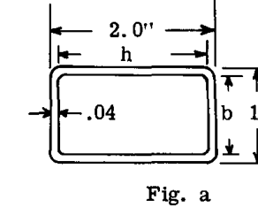

Fig. a

**解答:** 断面の面積 $A = 0.234\text{ in.}^2$ 。最小断面二次半径は $0.42\text{ インチ}$ である。

長さ 21 インチに対する柱破壊応力 $F_c$ を求める前に、圧壊応力 $F_{cs}$ および座屈応力 $F_{cr}$ を決定しなければならない。

圧壊応力は Gerard 法によって計算される。Fig. C7.7 で使用するパラメータは、

$$\frac{A}{g t^2} \left( \frac{F_{cy}}{E_c} \right)^{1/2} =
\frac{0.234}{12 \times 0.04^2} \left( \frac{67,000}{10,500,000}
\right)^{1/2} = 0.976$$

Fig. C7.7 より $F_{cs}/F_{cy} = 0.57$ となり、したがって $F_{cs} = 0.57 \times 67,000 = 38,200\text{ psi}$ である。

初期座屈応力 $F_{cr}$ は、第C6章の理論によって決定される。

第C6章の Fig. C6.6 より、 $K_h = 5.2$ である。

$$F_{cr} = \frac{5.2 \pi^2 \times 10,500,000}{12(1 - 0.3^2)} \left(
\frac{0.04}{1.92} \right)^2 = 21,500\text{ psi}$$

#### 方法1による柱強度 (Johnson-Eulerの式)

$$L = 21\text{ インチ}, \quad L' = L/\sqrt{c} = 21/\sqrt{1} = 21$$

$$L'/\rho = 21/0.42 = 50$$

Johnson-Euler の方程式は以下の通りである。

$$F_c = F_{cs} - \frac{F_{cs}^2}{4\pi^2 E} (L'/\rho)^2$$

これに代入すると、

$$F_c = 38,200 - \frac{38,200^2}{4\pi^2 \times 10,500,000} (50)^2 =
29,400\text{ psi}$$

この値は、Fig. C7.33 から $L'/\rho = 50$ 、および $L'/\rho = 0$ における $F_c = F_{cs} = 38,200$ の値に対して直接読み取ることもできる。

#### 方法2による柱強度

この方法は、与えられた材料および安定な断面に対する柱強度曲線を用いた作図を必要とする。

Fig. C7.35 は、安定な断面を持つ柱に対する我々の材料の柱曲線を示している。これは、第C2章の Fig. C2.10（室温条件）と同一であるが、Fig. C7.35 の曲線はより小さい垂直スケールで描かれている。

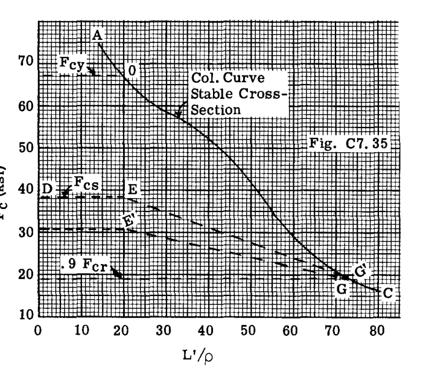

Fig. C7.35

圧壊応力と座屈応力の間の領域における柱強度曲線を得るための作図手順は以下の通りである。

柱応力 $F_c = F_{cy} = 67,000\text{ psi}$ において、水平線を描き、基本柱強度曲線との交点を点(O)とする。点(D)（圧壊応力 $38,200\text{ psi}$ に等しい）から水平線を描く。点(O)から垂直に下方に投影して点(E)を決定する。応力 $F_c = 0.9 F_{cr} = 0.9 \times 21,500 = 19,350\text{ psi}$ において点(G)を決定する。点(E)と(G)を直線で結ぶ。この直線は、点(E)と(G)の間の $L'/\rho$ 値に対する問題の部材の柱破壊曲線を表す。 $L'/\rho = 50$ として、EG 線まで上方に投影し、次に左側のスケールに水平に投影して $F_c = 27,700\text{ psi}$ を読み取る。

#### 方法3による柱強度

この方法では、式(C7.32)が使用される。

$$\frac{F_c}{F_{cs}} = 1 - \left(1 - \frac{F_{cr}}{F_{cs}}\right)
\left(\frac{F_{cr}}{F_E}\right) \qquad \text{--- (A)}$$

$$F_{cr} = 21,500, \quad F_{cs} = 38,200$$

$F_E$ は、安定な断面を持つ柱に対する Euler 応力である。 $F_E$ を見つけるために、Fig. C7.35 の曲線 AOC に対して $L'/\rho = 50$ から上方に投影し、次に水平に読み取って $F_c = F_E = 41,700\text{ psi}$ を得る。

式(A)に代入すると、

$$\frac{F_c}{38,200} = 1 - (1 - 21,500/38,200)(21,500/41,700)$$

$$F_c = 38,200(1 - 0.225) = 29,600\text{ psi}$$

### 例題2.

Fig. (b) に示すようなロール成形 Z 型断面が柱として使用されている。長さ $L = 30\text{ インチ}$ である。部材は $x-x$ 方向に支持されているため、柱の曲げ破壊は $x-x$ 軸まわりに発生しなければならない。材料はアルミニウム合金で、 $F_{cy} = 67,000$ 、および $E_c = 10,500,000$ である。端部固定度係数を $c = 1.5$ と仮定する。

柱の破壊応力を求めよ。

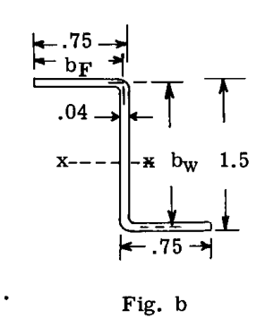

Fig. b

**解答:**

断面の面積 $= 0.117\text{ in.}^2$  
$\rho_x = 0.535\text{ in.}$

柱強度を求めるには、まず初期座屈応力が必要である。

$$b_w = 1.5 - 0.04 = 1.46, \quad b_f = 0.75 - 0.02 = 0.73$$

$$b_f/b_w = 0.73/1.46 = 0.5, \quad t_w/t_f = 1.0$$

第C6章の Fig. C6.4 より、 $K_w = 2.9$ である。

$$F_{cr} = \frac{2.9 \pi^2 \times 10,500,000}{12(1 - 0.3^2)} \left(
\frac{0.04}{1.46} \right)^2 = 20,900\text{ psi}$$

圧壊応力は、Z 型形状に適用される Fig. C7.9 を用いて Gerard 法によって計算される。下部スケールパラメータは、

$$\frac{A}{t^2} \left( \frac{F_{cy}}{E_c} \right)^{1/3} = \left(
\frac{0.117}{0.04^2} \right) \left( \frac{67,000}{10,500,000}
\right)^{1/3} = 13.6$$

Fig. C7.9 より、 $F_{cs}/F_{cy} = 0.455$ を読み取る。したがって、

$$F_{cs} = 67,000 \times 0.455 = 30,600\text{ psi}$$

#### 方法1による柱強度

$$L' = L/\sqrt{c} = 30/\sqrt{1.5} = 24.5$$

$$L'/\rho = 24.5/0.535 = 45.8$$

Johnson-Euler の方程式に代入すると、

$$F_c = 30,600 - \frac{30,600^2}{4\pi^2 \times 10,500,000} (45.8)^2 =
25,860\text{ psi}$$

#### 方法2による柱強度

Fig. C7.35 において、点 $E'$ は $F_c = F_{cs} = 30,600$ に配置される。点 $G'$ は $0.9 \times 20,900 = 18,800\text{ psi}$ に配置される。直線 $E'G'$ が柱強度曲線となる。 $L'/\rho = 45.8$ に対し、直線 $E'G'$ まで投影し、次に左側スケールへ水平に投影して $F_c = 25,000\text{ psi}$ を得る。

#### 方法3による柱強度

$F_E$ を見つけるために、Fig. C7.35 の $L'/\rho = 45.8$ および基本 Euler 曲線を使用して、 $F_E = 47,000\text{ psi}$ の値を得る。

式(A)に代入すると、

$$\frac{F_c}{30,600} = 1 - (1 - 20,900/30,600)(20,900/47,000)$$

$$F_c = 30,600(1 - 0.141) = 26,300\text{ psi}$$

## C7.28 有効幅を持つ外板を伴う補強材の柱強度

柱部材は、リベットやスポット溶接によって薄い外板に取り付けられることが多い。リベットの間隔がリベット間座屈を防止するよう適切に配置されている場合、外板は補強材が圧縮荷重を支持するのを補助するため、外板の効果を無視することは保守的すぎる設計となる。

取り付けられた外板が比較的薄い場合（すなわち、補強材の肉厚よりも薄い場合）、有効外板幅を柱断面積の一部として使用する方法が構造設計者に広く使用されており、この例題の解決にも使用される。

### 例題

例題として、例題2の Z 型補強材が、厚さ $0.025$ インチの同材質の外板にリベット接合された複数の補強材の1つであると仮定する。

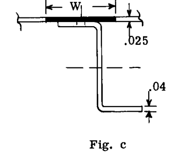

Fig. c

**解答:**

リベットまたはスポット溶接の間隔は、リベット間座屈を防ぐように設定されている。したがって、柱断面積は Fig. c に示すように、補強材の面積に有効幅 $w$ の外板の面積を加えたものとなる。有効外板幅 $w$ は補強材の応力の関数であり、また、補強材の応力は断面二次半径の関数であるため、設計手順は試行錯誤（反復計算）のプロセスとなる。

#### 第1回試行

有効外板幅は、補強材単体として作用する柱強度に基づくと仮定する。例題2の解決における3つの方法による平均的な柱破壊応力は、 $(25,860 + 25,000 + 26,300)/3 = 25,700\text{ psi}$ であった。

使用される有効幅の式は、

$$w = 1.9 t \sqrt{E/F_{ST}}$$

$$= 1.9 \times 0.025 \times \sqrt{10,500,000 / 25,700} = 0.965\text{ in.}$$

有効外板断面積 $= 0.965 \times 0.025 = 0.0242\text{ in.}^2$

補強材の面積 $= A_o = 0.117\text{ in.}^2$

総断面積 $= 0.1412\text{ in.}^2$

ここで、  
$\rho_o =$ 補強材単体の断面二次半径。  
$\rho =$ 外板と補強材を合わせた断面二次半径。  
$S =$ 外板の中心線から補強材の図心軸までの距離。  
$t =$ 外板の厚さ。  
$w =$ 外板の有効幅。

式(C7.33)は Fig. C7.36 に示すように曲線形式で表されており、これを用いて補強材に有効外板を加えた場合の断面二次半径 $\rho_o$ を計算する。

$$S = 0.75 + 0.0125 = 0.7625$$

補強材単体の $\rho_o = 0.535$

$$S/\rho_o = 0.7625/0.535 = 1.425$$

$$w = 0.965$$

$$wt/A_o = 0.965 \times 0.025 / 0.117 = 0.2063$$

$S/\rho_o$ および $wt/A_o$ の上記値に対して Fig. C7.36 から以下を得る。

$$(\rho/\rho_o)^2 = 1.05$$

これより、

$$\rho^2 = 0.535^2 \times 1.05$$

これは $\rho = 0.548\text{ in.}$ を与える。

したがって、

$$L'/\rho = 24.5/0.548 = 44.8$$

柱強度に対して方法1を使用すると、

$$F_c = 30,600 - \frac{30,600^2}{4\pi^2 \times 10,500,000} (44.8)^2 =
26,050\text{ psi}$$

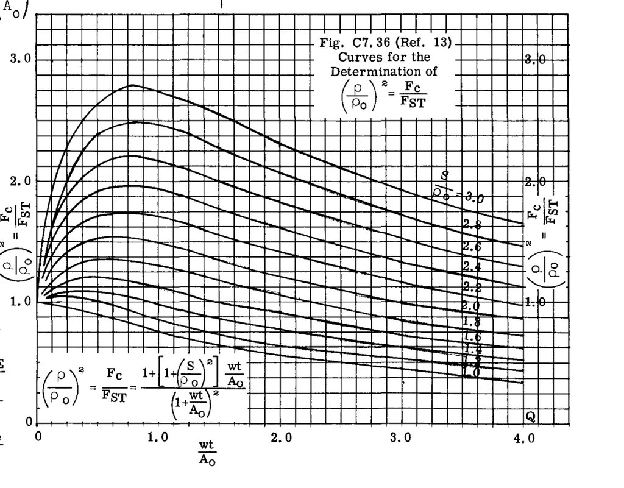

Fig. C7.36

## C7.29 比較的厚い外板を持つ外板・補強材パネル

局所破壊応力に関して前に議論した Z、Y、およびハット型の補強材・外板パネルについて、断面二次半径の計算において外板と補強材の全断面積を使用する。言い換えれば、有効外板幅を使用せず、外板全体を有効として使用する。

# 問題

1. 以下の材料から成形された場合について、Fig. (a) および (b) のアングル断面の圧壊応力を求めよ。Needham 法と Gerard 法の両方を使用せよ。
2. 2024-T3 アルミニウム合金。
3. 7075-T6 アルミニウム合金。
4. 17-7PH (TH1050) ステンレス鋼。
5. (3)と同様であるが、 $700^{\circ}\text{F}$ の高温に 1/2 時間さらされた場合。

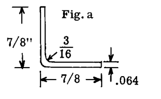

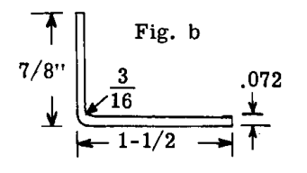

2. 以下の材料から成形された場合について、Fig. (c) および (d) の2つのチャンネル形状の圧壊応力を求めよ。
3. $F_{tu} = 180,000$ に熱処理された AISI 4130 鋼。
4. (1)と同様であるが、 $500^{\circ}\text{F}$ の高温に 1/2 時間さらされた場合。
5. Ti-8Mn チタニウム。
6. 7075-T6 アルミニウム合金。

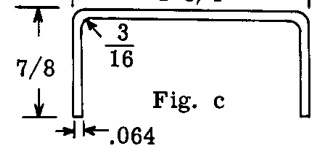

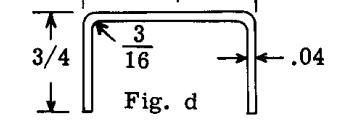

3. 以下の材料から成形された場合について、Fig. (e) および (f) の矩形管の圧壊応力を求めよ。
4. 2024-T3 アルミニウム合金。
5. HK31A-O マグネシウム。
6. Ti-8Mn チタニウム。
7. (2)と同様であるが、 $300^{\circ}\text{F}$ の高温に 1/2 時間さらされた場合。

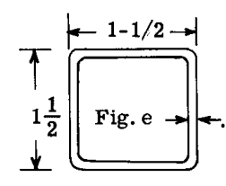

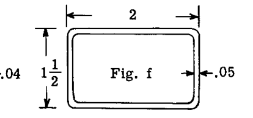

4. 2024-T3 および 7075-T6 アルミニウム合金材料から成形された場合について、Fig. (g) および (h) の断面の圧壊応力を求めよ。

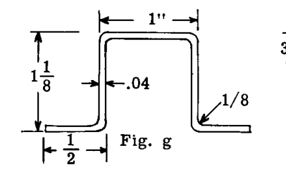

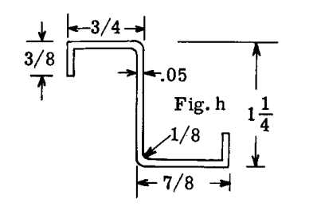

5. 第A3章の Table A3.16 に示されている、押出成形セクション番号 4, 8, 16, 22, 28 および 34 の圧壊応力を求めよ。材料は 2014-T3 アルミニウム合金である。
6. Fig. i は、補強された翼断面におけるコーナー部材を示している。外板は、1/8 径のリベットを用いて 3/4 インチ間隔で1列で補強材に固定されている。ウェブは、各 1-1/8 インチの間隔で2列の千鳥配置のリベットによって補強材に固定されており、リベットは皿頭タイプである。材料は 2024-T3 アルミニウム合金である。また、7075-T6 アルミニウム材料についても計算せよ。

補強材の圧壊応力を求めよ。リベット間座屈が発生するか。有効外板幅と、総破壊荷重ユニットを求めよ。

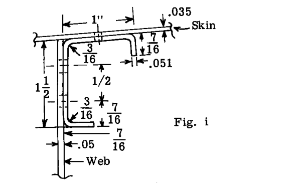

Fig. i

7. Fig. C7.29 に示されているような、短い Z 型補強外板パネルユニットの圧縮破壊強度を決定せよ。各種寸法は以下の通りである。記号の意味については Fig. C7.29 を参照のこと。

$$t_w = 0.072, \quad b_F = 1.0, \quad b_S = 2.50$$

$$t_s = 0.072, \quad b_A = 0.625$$

$$b_w = 2.50, \quad b_o = 0.375$$

補強材および外板の材料は 2024-T3 アルミニウム合金である。リベットは 1/8 径の丸頭（Brazier Head）タイプ 2117-T3 材料であり、7/8 インチ間隔で配置されている。

## 参考文献

1. Needham, R. A.:- The Ultimate Strength of Aluminum Alloy Formed Structural Shapes in Compression. Jour. Aero. Sci. Vol. 21, April, 1954.
2. Gerard, G.:- Handbook of Structural Stability. Part IV. Failure of Plates and Composite Elements. NACA TN 3784, August, 1957.
3. Gerard, G.:- The Crippling Strength of Compression Elements. Jour. Aero. Sci., Vol. 25, Jan. 1958.
4. Coan, J. M.:- Large Deflection Theory for Plates with Small Initial Curvature Loaded in Compression. Jr. Applied Mech., Vol. 18, June 1951.
5. Windenberg, D. F.:- Proc. 5th International Congress for Applied Mechanics. pp. 54-61, 1939.
6. Experimental Study of Deformation and Effective Widths in Axially Loaded Sheet Stringer Panels. NACA TN 684, 1939.
7. Gerard, G.:- Effective Width of Elastically Supported Flat Plates. Jour. Aero. Sci., Vol. 13, Oct. 1946.
8. Howland, W. L.:- Effect of Rivet Spacing on Stiffened Thin Sheet in Compression. Jour. Aero. Sci., Vol. 3, Oct. 1936.
9. Argyris, J. H. and Dunne, P. C.:- Structural Principles and Data. Handbook of Aero., 4th Edition, 1952.
10. Bizlaard, P. P. and Johnston, G. S.:- Compression Buckling of Plates Due to Forced Crippling of Stiffeners. Preprint No. 408. S.M.F. Fund Paper. Inst. of Aero Sci. Jan. 1953.
11. Semonian, J. W. and Peterson, J. P.:- An Analysis of the Stability and Ultimate Compressive Strength of Short Sheet-Stringer Panels with Special Reference to the Influence of Riveted Connection Between Sheet and Stringer. NACA TN 3431, March, 1955.
12. Gerard, G.:- Handbook of Structural Stability, Part V. Compressive Strength of Flat Stiffened Panels. NACA TN 3785, Aug. 1957.
13. Thesis by R. J. White:- The Ultimate Compressive Strength of Thin Sheet Metal Panels. Appendix A. C.I.T. 1935.